# Basic Plotting

Sean Kross

January 9, 2016

### Scatter Plots

R is known for producing graphics, and quickly producing graphics is a wonderful way to explore a dataset. Plots are generated by providing data to plotting functions. The first plotting function we’ll discuss is `plot()`. The `plot()` function can take many different arguments but most of them have default values.

The most simple way to use `plot()` is just providing the function with one argument, a numeric vector:

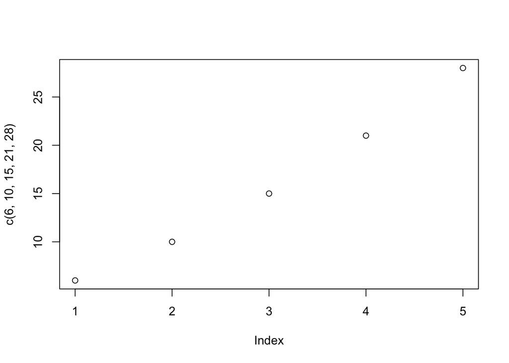

```r
plot(c(6, 10, 15, 21, 28))
```

How easy is that!? As you can see the index of each element of the vector is plotted on the x-axis and the value of each element of the vector is plotted on the y-axis. If you provide two different vectors as arguments to `plot()` the first vector will determine the x-coordinates and the second vector will determine the y-coordinates:

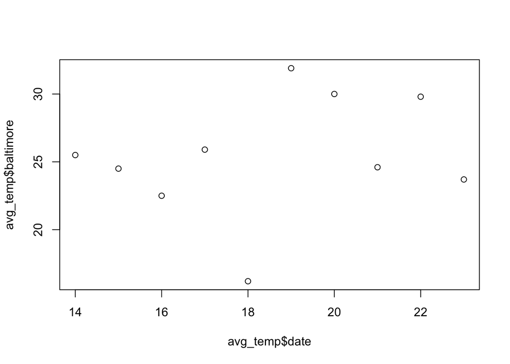

```r
# Let's make a data frame with some fake average temperature data
avg_temp <- data.frame(
  baltimore = c(25.5, 24.5, 22.5, 25.9, 16.2, 31.9, 30.0, 24.6, 29.8, 23.7),
  chicago = c(22.3, 27.0, 22.5, 22.3, 30.1, 29.0, 26.2, 24.5, 23.4, 28.0),
  date = 14:23
)

plot(avg_temp$date, avg_temp$baltimore)
```

Let’s make this plot look a little nicer. First we’ll add labels for the x and y axes by specifying the arguments `xlab` and `ylab`:

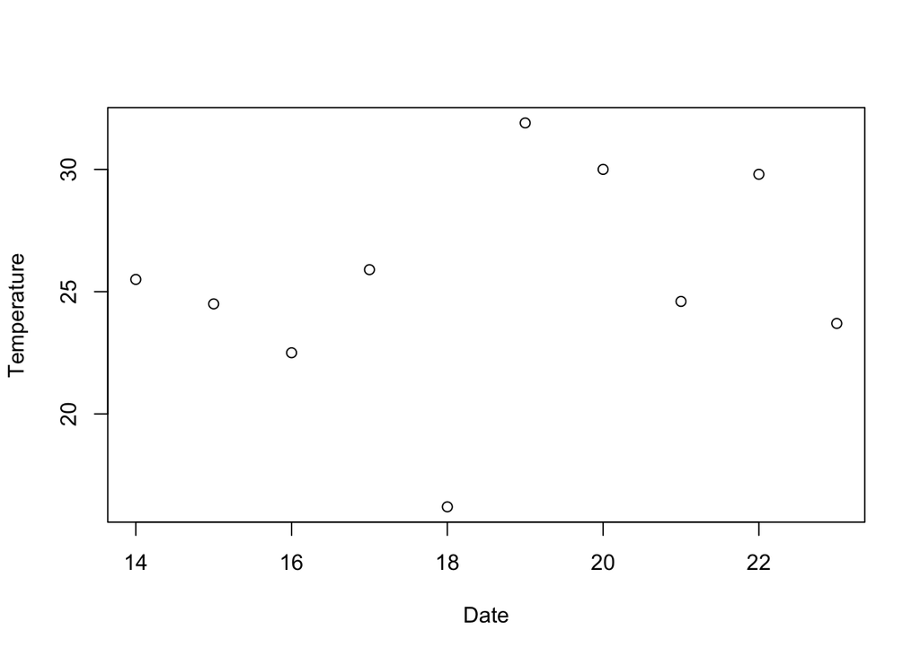

```r
plot(avg_temp$date, avg_temp$baltimore, xlab = "Date", ylab = "Temperature")
```

We can add a title to the plot by using the `main` argument:

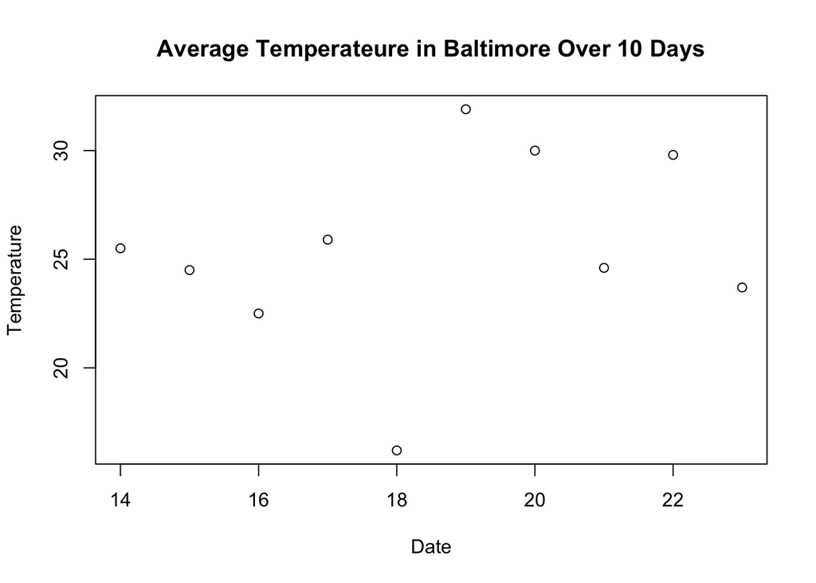

```r
plot(avg_temp$date, avg_temp$baltimore, xlab = "Date", ylab = "Temperature",
     main = "Average Temperateure in Baltimore Over 10 Days")
```

### Line Plots

Since we’re trying to see how the average temperature changed over time, perhaps this would look better as a line graph. We can turn this into a line graph by specifying the `type` argument:

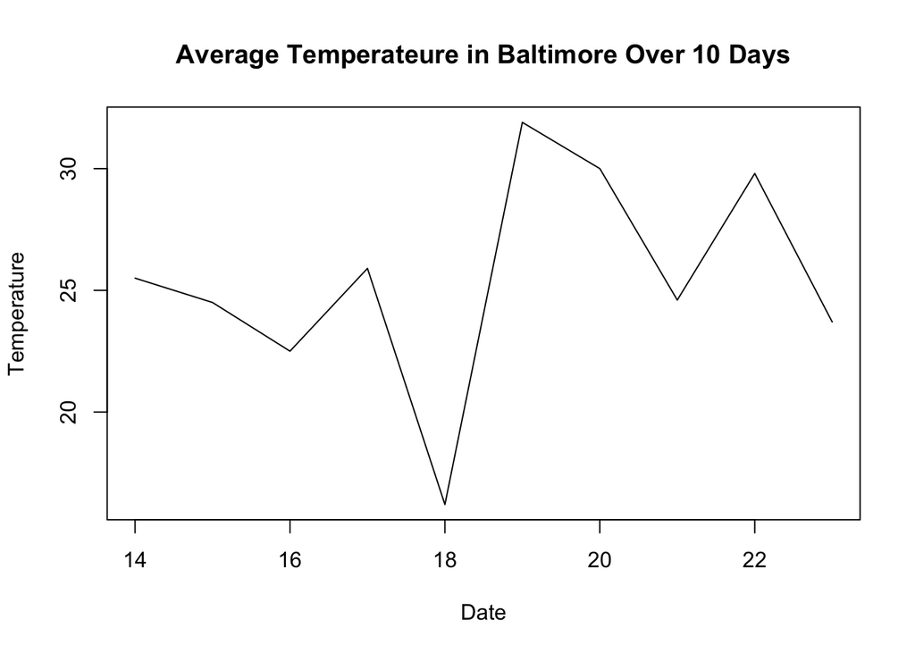

```r
plot(avg_temp$date, avg_temp$baltimore, xlab = "Date", ylab = "Temperature",
     main = "Average Temperateure in Baltimore Over 10 Days", type = "l")
```

We made some fake data for temperatures in Chicago too, so let’s add those values to this plot. We can do this using the `lines()` function, which allows us to layer a line on top of a graph we’ve already created. Notice that the `lines()` function takes the same arguments as the `plot()` function:

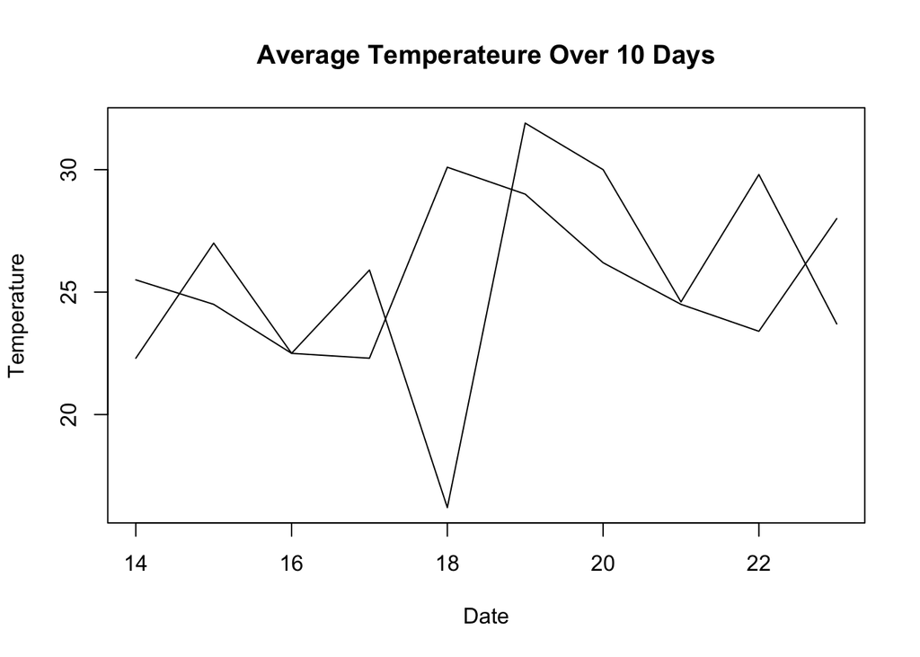

```r
plot(avg_temp$date, avg_temp$baltimore, xlab = "Date", ylab = "Temperature",
     main = "Average Temperateure Over 10 Days", type = "l")
lines(avg_temp$date, avg_temp$chicago)
```

Uh-oh, there’s no way to differentiate the two lines! First let’s use the `col` argument to color the line for temperatures in Chicago:

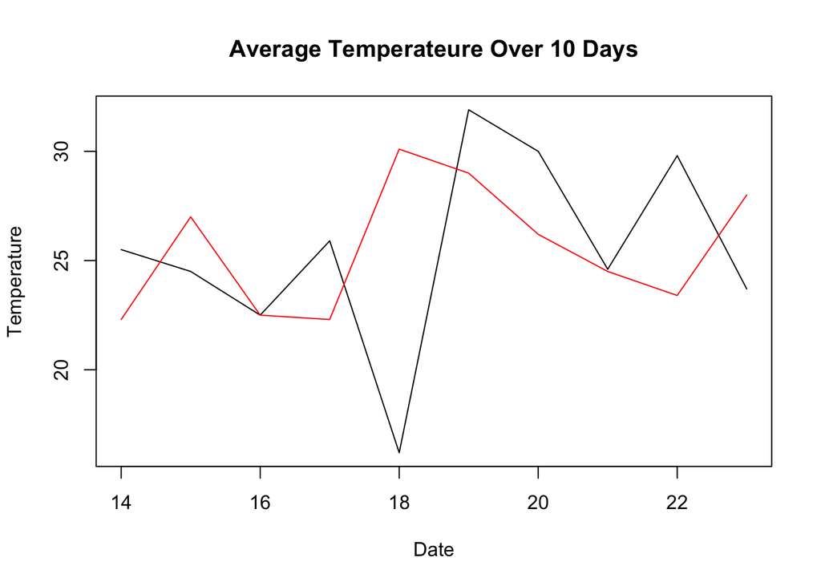

```r
plot(avg_temp$date, avg_temp$baltimore, xlab = "Date", ylab = "Temperature",
     main = "Average Temperateure Over 10 Days", type = "l")
lines(avg_temp$date, avg_temp$chicago, col = "red")
```

That’s much better! Now let’s add a legend so we know which line corresponds to which city. We can layer on a legend using the `legend` function. The `legend` function can potentially take many arguments, but most of the arguments have defaults. Each argument below has a comment which explains its purpose.

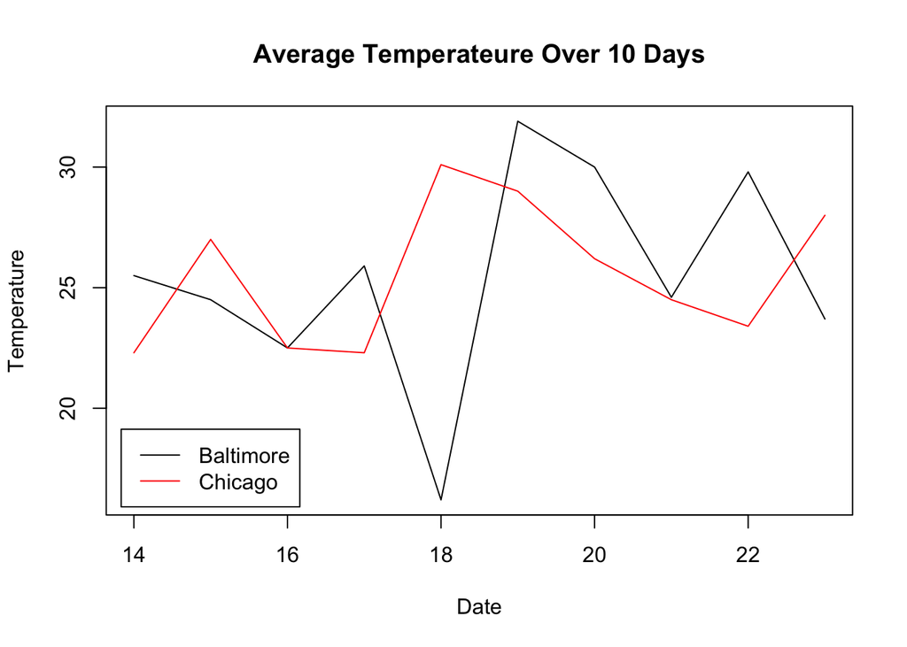

```r
plot(avg_temp$date, avg_temp$baltimore, xlab = "Date", ylab = "Temperature",
     main = "Average Temperateure Over 10 Days", type = "l")
lines(avg_temp$date, avg_temp$chicago, col = "red")
legend("bottomleft",              # specifies the location of the legend
       c("Baltimore", "Chicago"), # Adds strings to the legend
       lty = 1,                   # Draws a line next to each string
       col = c("black", "red"),   # colors each line
       inset=c(.02,.02))          # moves the legend away from each axis a little
```

### Histograms

Histograms are great for visualizing counts and examining how frequencies of events are distributed. We can use the `hist()` function to make histrograms. The `hist()` function can take many parameters but like `plot()` we can get away with just providing a single vector as an argument:

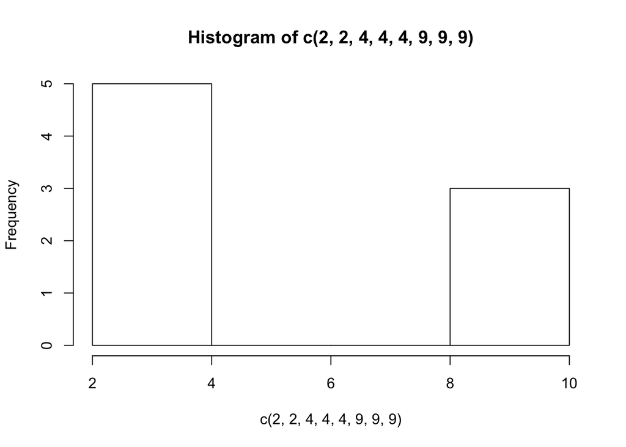

```r
hist(c(2, 2, 4, 4, 4, 9, 9, 9))
```

It’s difficult to show the usefulness of `hist()` using fake data like, so let’s pull in some of the lego set data we worked with in lecture 2 so we can visualize how the number of minifigures per set is distributed:

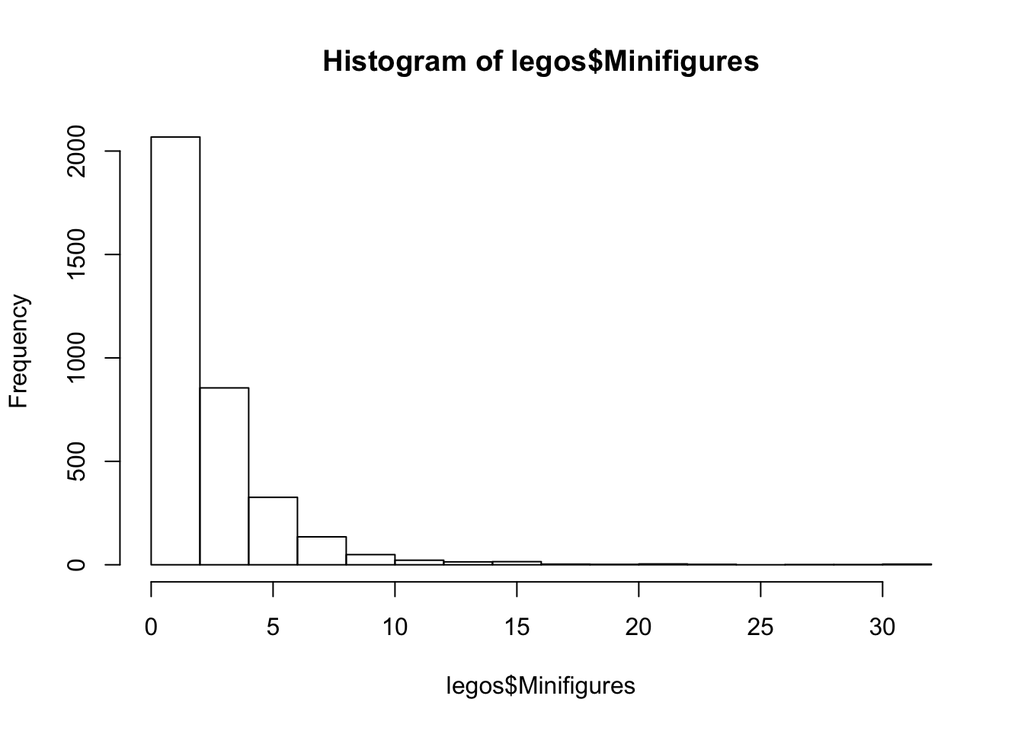

```r
legos <- read.csv("https://raw.githubusercontent.com/seankross/lego/master/data-tidy/legosets.csv", stringsAsFactors = FALSE)

hist(legos$Minifigures)
```

We can specify many of the same arguments when using `hist()` as we did when using `plot()`, like `xlab` for labelling the x-axis and `main` for adding a title.

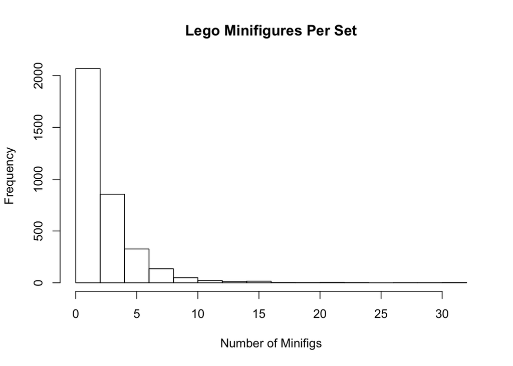

```r
hist(legos$Minifigures, xlab = "Number of Minifigs",
     main = "Lego Minifigures Per Set")
```

If we want a more granular look at the number of minifigures per set we can increase the number of bars in the plot by adding the `breaks` argument:

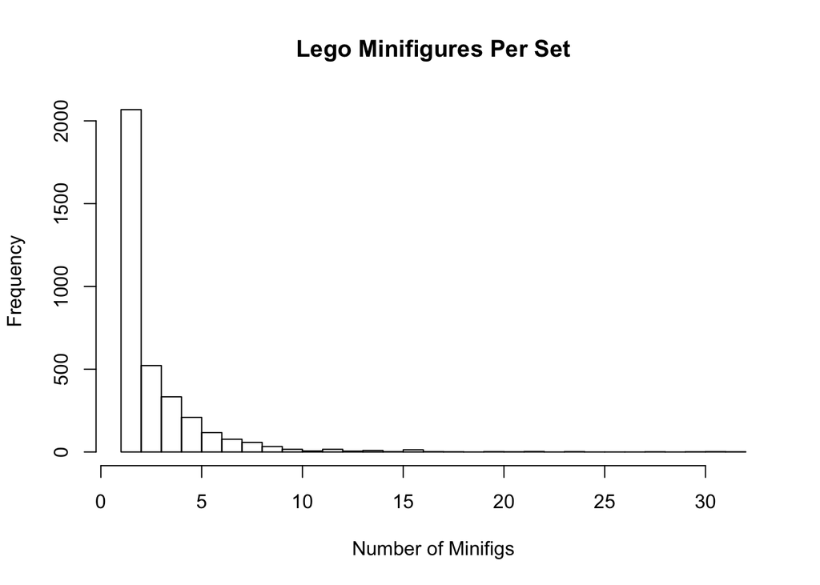

```r
hist(legos$Minifigures, xlab = "Number of Minifigs",
     main = "Lego Minifigures Per Set", breaks = 30)
```

### Boxplots

Another type of plot for examining distributions and identifying outliers is a boxplot. Let’s make a simple boxplot using the Baltimore temperature data from before:

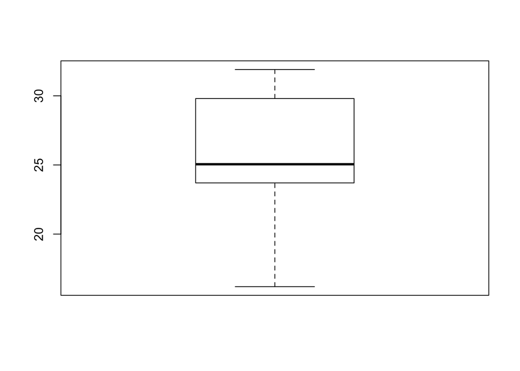

```r
boxplot(avg_temp$baltimore)
```

By providing two vectors, we can see two boxplots next to each other:

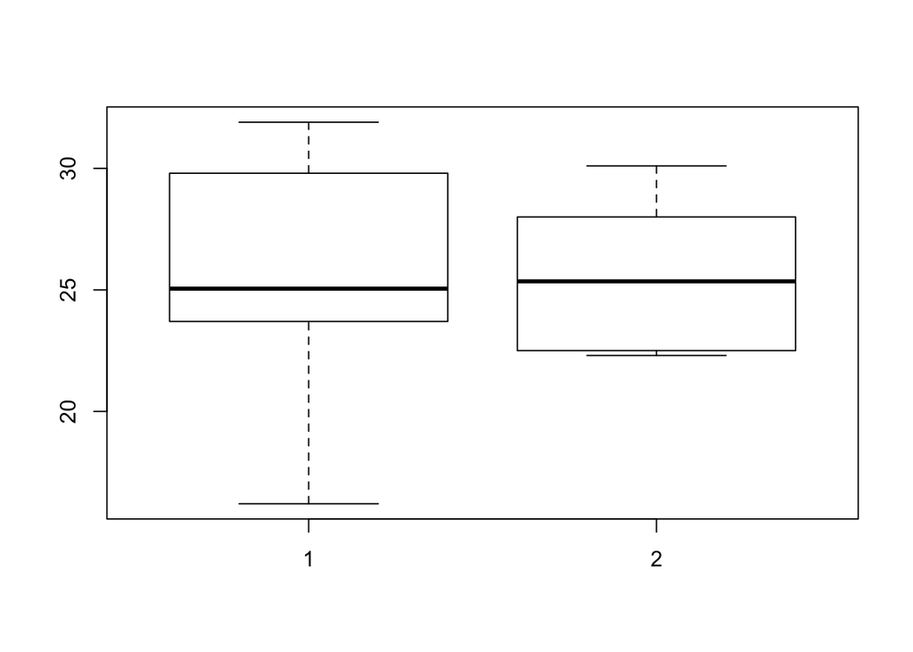

```r
boxplot(avg_temp$baltimore, avg_temp$chicago)
```

Like in previous exampels we can add names, axis labels, and a title:

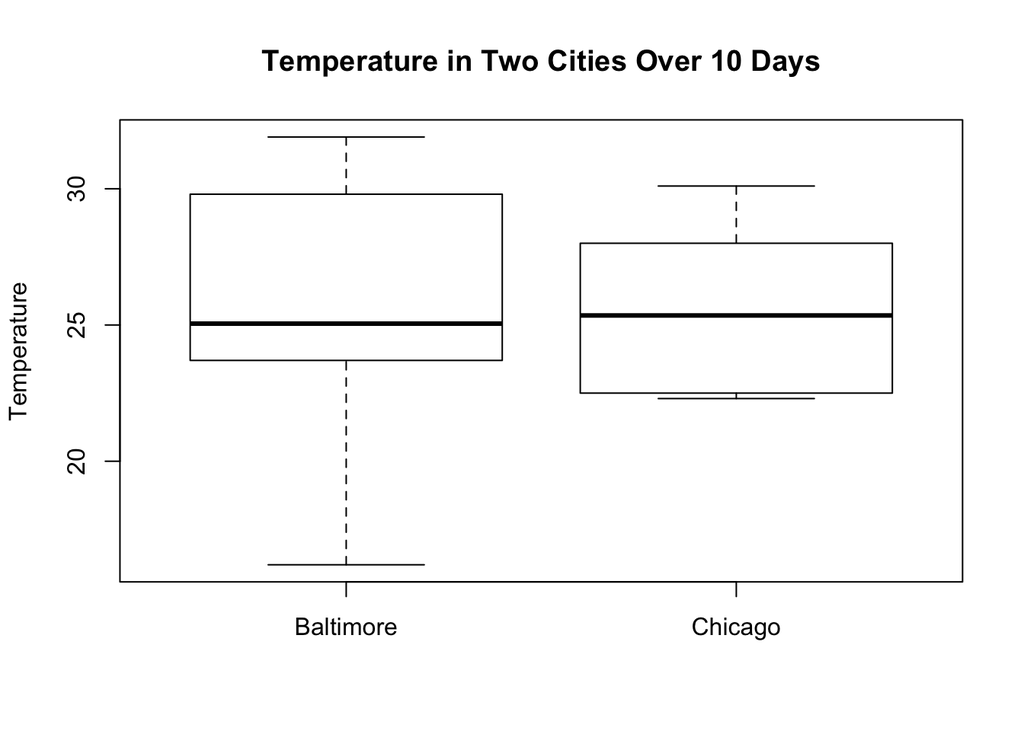

```r
boxplot(avg_temp$baltimore, avg_temp$chicago,
        names = c("Baltimore", "Chicago"),
        main = "Temperature in Two Cities Over 10 Days",
        ylab = "Temperature")
```